# ¿Qué es graficar bien?

Por: Dan Jinich

https://github.com/danjinich/Curso-python

## ¿Qué es graficar?

- Comunicar una idea o una historia lo mas eficientemente posible.
- Puede ser exploratorio o explicativo.

## ¿Comó?

1. Situación retorica.
2. Escoger el tipo correcto.
3. Eliminar lo que no aumenta valor.
4. Llamar la atención del lector a lo más importante.
5. Usarlo como herramienta para contar una historia.

http://www.vizwiz.com/2013/01/alberto-cairo-three-steps-to-become.html

```python
import pandas as pd
import matplotlib.pyplot as plt
import seaborn as sns
```

## Gráficas exploratorias v.s. explicativas

- Las gráficas exploratorias son para cuando tu estas solo con tus datos, tratas de entender que esta pasando.
- Las gráficas explicativas son para cuando quieres compartir tus datos, presentar una historia.

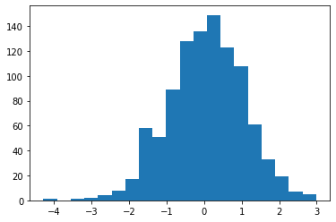

```python
plt.hist(s, bins=20)
plt.show()
```

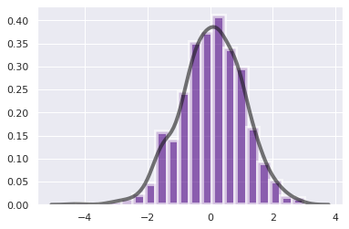

```python
sns.set(style="darkgrid")
sns.distplot(s, bins=20,
             kde_kws={"color": "k", "lw": 3,
                      "alpha":.6, "lw":4},
             hist_kws={"histtype": "bar", "linewidth": 5,
                       "alpha": .6, "color": "indigo"})
plt.show()
```

```python
datasaurus.head()
```

|  | dataset | x | y |
| --- | --- | --- | --- |
| 0 | dino | 55.3846 | 97.1795 |
| 1 | dino | 51.5385 | 96.0256 |
| 2 | dino | 46.1538 | 94.4872 |
| 3 | dino | 42.8205 | 91.4103 |
| 4 | dino | 40.7692 | 88.3333 |

```python
datasaurus.groupby("dataset").describe()
```

| dataset | x count | x mean | x std | x min | x 25% | x 50% | x 75% | x max | y count | y mean | y std | y min | y 25% | y 50% | y 75% | y max |
| --- | --- | --- | --- | --- | --- | --- | --- | --- | --- | --- | --- | --- | --- | --- | --- | --- |
| away | 142.0 | 54.266100 | 16.769825 | 15.560750 | 39.724115 | 53.340296 | 69.146597 | 91.639961 | 142.0 | 47.834721 | 26.939743 | 0.015119 | 24.625892 | 47.535269 | 71.803148 | 97.475771 |
| bullseye | 142.0 | 54.268730 | 16.769239 | 19.288205 | 41.627968 | 53.842088 | 64.798900 | 91.735539 | 142.0 | 47.830823 | 26.935727 | 9.691547 | 26.244735 | 47.382937 | 72.532852 | 85.876229 |
| circle | 142.0 | 54.267320 | 16.760013 | 21.863581 | 43.379116 | 54.023213 | 64.972672 | 85.664761 | 142.0 | 47.837717 | 26.930036 | 16.326546 | 18.349610 | 51.025022 | 77.782382 | 85.578134 |
| dino | 142.0 | 54.263273 | 16.765142 | 22.307700 | 44.102600 | 53.333300 | 64.743600 | 98.205100 | 142.0 | 47.832253 | 26.935403 | 2.948700 | 25.288450 | 46.025600 | 68.525675 | 99.487200 |
| dots | 142.0 | 54.260303 | 16.767735 | 25.443526 | 50.359707 | 50.976768 | 75.197363 | 77.954435 | 142.0 | 47.839829 | 26.930192 | 15.771892 | 17.107141 | 51.299291 | 82.881589 | 94.249328 |
| h_lines | 142.0 | 54.261442 | 16.765898 | 22.003709 | 42.293828 | 53.069678 | 66.768274 | 98.288123 | 142.0 | 47.830252 | 26.939876 | 10.463915 | 30.479911 | 50.473527 | 70.349471 | 90.458936 |
| high_lines | 142.0 | 54.268805 | 16.766704 | 17.893499 | 41.535981 | 54.168689 | 63.952667 | 96.080519 | 142.0 | 47.835450 | 26.939998 | 14.913962 | 22.920843 | 32.499203 | 75.940022 | 87.152208 |
| slant_down | 142.0 | 54.267849 | 16.766759 | 18.109472 | 42.890931 | 53.135159 | 64.469989 | 95.593416 | 142.0 | 47.835896 | 26.936105 | 0.303872 | 27.840858 | 46.401314 | 68.439430 | 99.644179 |
| slant_up | 142.0 | 54.265882 | 16.768853 | 20.209778 | 42.810866 | 54.261345 | 64.488010 | 95.260528 | 142.0 | 47.831496 | 26.938608 | 5.645777 | 24.756248 | 45.292238 | 70.855844 | 99.579591 |
| star | 142.0 | 54.267341 | 16.768959 | 27.024603 | 41.034210 | 56.534732 | 68.711493 | 86.435897 | 142.0 | 47.839545 | 26.930275 | 14.365590 | 20.374135 | 50.110554 | 63.548584 | 92.214989 |
| v_lines | 142.0 | 54.269927 | 16.769959 | 30.449654 | 49.964506 | 50.362890 | 69.504068 | 89.504851 | 142.0 | 47.836988 | 26.937684 | 2.734760 | 22.752884 | 47.113616 | 65.845391 | 99.694680 |
| wide_lines | 142.0 | 54.266916 | 16.770000 | 27.439632 | 35.522449 | 64.550226 | 67.453672 | 77.915874 | 142.0 | 47.831602 | 26.937902 | 0.217006 | 24.346941 | 46.279331 | 67.568127 | 99.283764 |
| x_shape | 142.0 | 54.260150 | 16.769958 | 31.106867 | 40.091656 | 47.136458 | 71.856923 | 85.446186 | 142.0 | 47.839717 | 26.930002 | 4.577661 | 23.470809 | 39.876211 | 73.609634 | 97.837615 |

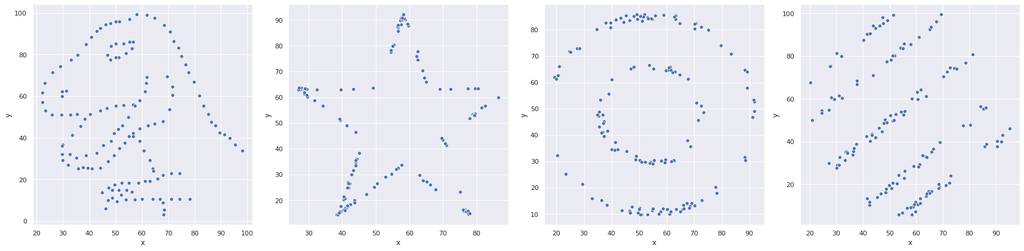

```python
f = plt.figure(figsize=(24, 6))
gs = f.add_gridspec(1, 4)

ax = f.add_subplot(gs[0, 0])
sns.scatterplot(data=datasaurus[datasaurus['dataset']=='dino'],
                x='x', y='y', ax=ax)

ax = f.add_subplot(gs[0, 1])
sns.scatterplot(data=datasaurus[datasaurus['dataset']=='star'],
                x='x', y='y', ax=ax)

ax = f.add_subplot(gs[0, 2])
sns.scatterplot(data=datasaurus[datasaurus['dataset']=='bullseye'],
                x='x', y='y', ax=ax)

ax = f.add_subplot(gs[0, 3])
sns.scatterplot(data=datasaurus[datasaurus['dataset']=='slant_up'],
                x='x', y='y', ax=ax)

f.tight_layout()
```

## Tipos de datos

- Continuos
- Discretos
- Categóricos
  - Ordenados
  - No ordenados

¿Qué tipo de visualización es la correcta para todas las combinaciones?

## ¿Comó graficar?

https://www.gapminder.org

## Mejores formas de mapear información

1. Posición
2. Largo
3. Ángulo o pendiente
4. Área
5. Volumen
6. Color o densidad

https://web.cs.dal.ca/~sbrooks/csci4166-6406/seminars/readings/Cleveland_GraphicalPerception_Science85.pdf

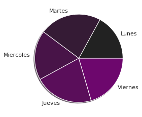

```python
sns.set_palette(sns.dark_palette("purple"))

plt.pie(shadow=True, x=val['b'], labels=val['a'])
plt.show()
```

- Mala elección de color.
- La sombra.
- Es de pie, entonces no sabemos que dice.

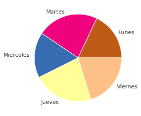

```python
sns.set_palette("Accent_r")

plt.pie(x=val['b'], labels=val['a'])
plt.show()
```

- Mejor elección de color, pero sigue sin estar bien.
- No se puede entender toda la información.

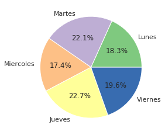

```python
sns.set_palette("Accent")
plt.pie(x=val['b'], labels=val['a'], autopct='%1.1f%%')
plt.show()
```

### Solución:

Friends don't let friends do pie charts.

## Escoger colores

1. Considera la rueda

[figure not shown]

1. Asegurate de conocer las implicaciones que tienen los colores que escogiste.

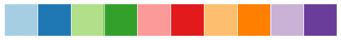

```python
sns.palplot(sns.color_palette("Paired", 10))
```

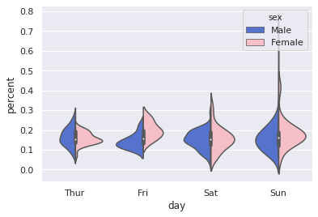

```python
sns.violinplot(x="day", y="percent",
               hue="sex", data=tip, split=True,
               palette=['royalblue','lightpink'])
```

1. Manten un tema constante. Acuerdate que estas contando una historia.
2. Usa las diferencias de color para mostrar importancia.
3. Asegurate que tus gráficas se entiendan en blanco y negro.
1. Escoge el tipo de paleta de color apropiado.

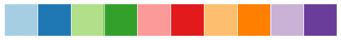

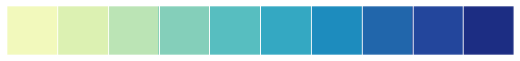

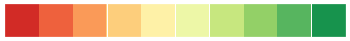

```python
sns.palplot(sns.color_palette("Paired", 10))
sns.palplot(sns.color_palette("YlGnBu", 10))
sns.palplot(sns.color_palette("RdYlGn", 10))
```

## Algunos links útiles

- https://cfwebprod.sandia.gov/cfdocs/CompResearch/docs/ColorMapsExpanded.pdf
- http://paletton.com/
- https://learnui.design/tools/data-color-picker.html